# HM5

狄豪飛

2023-10-24

## Student Stress Factors: A Comprehensive Analysis

It contains various features that impact a student’s stress level, grouped into Psychological, Physiological, Environmental, Academic, and Social factors.

### Understand the Dataset and Objectives

#### Dataset Overview:

Psychological Factors: anxiety_level, self_esteem, mental_health_history, depression

Physiological Factors: headache, blood_pressure, sleep_quality, breathing_problem

Environmental Factors: noise_level, living_conditions, safety, basic_needs

Academic Factors: academic_performance, study_load, teacher_student_relationship, future_career_concerns

Social Factor: social_support, peer_pressure, extracurricular_activities, bullying

Objectives: To understand which features have the most impact on a student’s stress level.

```r
# Cargar el conjunto de datos
df <- read.csv("C:/Users/georg/OneDrive/Desktop/Data Science/HM5/HM5/StressLevelDataset.csv")

# Visualizar las primeras filas del conjunto de datos
head(df)
```

```
##   anxiety_level self_esteem mental_health_history depression headache
## 1            14          20                     0         11        2
## 2            15           8                     1         15        5
## 3            12          18                     1         14        2
## 4            16          12                     1         15        4
## 5            16          28                     0          7        2
## 6            20          13                     1         21        3
##   blood_pressure sleep_quality breathing_problem noise_level living_conditions
## 1              1             2                 4           2                 3
## 2              3             1                 4           3                 1
## 3              1             2                 2           2                 2
## 4              3             1                 3           4                 2
## 5              3             5                 1           3                 2
## 6              3             1                 4           3                 2
##   safety basic_needs academic_performance study_load
```

[output cut: 20 more lines]

```r
# Obtener un resumen estadístico
summary(df)
```

```
##  anxiety_level    self_esteem    mental_health_history   depression
##  Min.   : 0.00   Min.   : 0.00   Min.   :0.0000        Min.   : 0.00
##  1st Qu.: 6.00   1st Qu.:11.00   1st Qu.:0.0000        1st Qu.: 6.00
##  Median :11.00   Median :19.00   Median :0.0000        Median :12.00
##  Mean   :11.06   Mean   :17.78   Mean   :0.4927        Mean   :12.56
##  3rd Qu.:16.00   3rd Qu.:26.00   3rd Qu.:1.0000        3rd Qu.:19.00
##  Max.   :21.00   Max.   :30.00   Max.   :1.0000        Max.   :27.00
##     headache     blood_pressure  sleep_quality  breathing_problem
##  Min.   :0.000   Min.   :1.000   Min.   :0.00   Min.   :0.000
##  1st Qu.:1.000   1st Qu.:1.000   1st Qu.:1.00   1st Qu.:2.000
##  Median :3.000   Median :2.000   Median :2.50   Median :3.000
##  Mean   :2.508   Mean   :2.182   Mean   :2.66   Mean   :2.754
##  3rd Qu.:3.000   3rd Qu.:3.000   3rd Qu.:4.00   3rd Qu.:4.000
##  Max.   :5.000   Max.   :3.000   Max.   :5.00   Max.   :5.000
##   noise_level    living_conditions     safety       basic_needs
##  Min.   :0.000   Min.   :0.000     Min.   :0.000   Min.   :0.000
##  1st Qu.:2.000   1st Qu.:2.000     1st Qu.:2.000   1st Qu.:2.000
##  Median :3.000   Median :2.000     Median :2.000   Median :3.000
##  Mean   :2.649   Mean   :2.518     Mean   :2.737   Mean   :2.773
##  3rd Qu.:3.000   3rd Qu.:3.000     3rd Qu.:4.000   3rd Qu.:4.000
##  Max.   :5.000   Max.   :5.000     Max.   :5.000   Max.   :5.000
##  academic_performance   study_load    teacher_student_relationship
##  Min.   :0.000        Min.   :0.000   Min.   :0.000
##  1st Qu.:2.000        1st Qu.:2.000   1st Qu.:2.000
##  Median :2.000        Median :2.000   Median :2.000
##  Mean   :2.773        Mean   :2.622   Mean   :2.648
##  3rd Qu.:4.000        3rd Qu.:3.000   3rd Qu.:4.000
##  Max.   :5.000        Max.   :5.000   Max.   :5.000
##  future_career_concerns social_support  peer_pressure
##  Min.   :0.000          Min.   :0.000   Min.   :0.000
##  1st Qu.:1.000          1st Qu.:1.000   1st Qu.:2.000
##  Median :2.000          Median :2.000   Median :2.000
##  Mean   :2.649          Mean   :1.882   Mean   :2.735
##  3rd Qu.:4.000          3rd Qu.:3.000   3rd Qu.:4.000
##  Max.   :5.000          Max.   :3.000   Max.   :5.000
##  extracurricular_activities    bullying      stress_level
##  Min.   :0.000              Min.   :0.000   Min.   :0.0000
##  1st Qu.:2.000              1st Qu.:1.000   1st Qu.:0.0000
##  Median :2.500              Median :3.000   Median :1.0000
##  Mean   :2.767              Mean   :2.617   Mean   :0.9964
##  3rd Qu.:4.000              3rd Qu.:4.000   3rd Qu.:2.0000
##  Max.   :5.000              Max.   :5.000   Max.   :2.0000
```

```r
# Verificar los tipos de datos de cada columna
str(df)
```

```
## 'data.frame':    1100 obs. of  21 variables:
##  $ anxiety_level               : int  14 15 12 16 16 20 4 17 13 6 ...
##  $ self_esteem                 : int  20 8 18 12 28 13 26 3 22 8 ...
##  $ mental_health_history       : int  0 1 1 1 0 1 0 1 1 0 ...
##  $ depression                  : int  11 15 14 15 7 21 6 22 12 27 ...
##  $ headache                    : int  2 5 2 4 2 3 1 4 3 4 ...
##  $ blood_pressure              : int  1 3 1 3 3 3 2 3 1 3 ...
##  $ sleep_quality               : int  2 1 2 1 5 1 4 1 2 1 ...
##  $ breathing_problem           : int  4 4 2 3 1 4 1 5 4 2 ...
##  $ noise_level                 : int  2 3 2 4 3 3 1 3 3 0 ...
##  $ living_conditions           : int  3 1 2 2 2 2 4 1 3 5 ...
##  $ safety                      : int  3 2 3 2 4 2 4 1 3 2 ...
##  $ basic_needs                 : int  2 2 2 2 3 1 4 1 3 2 ...
##  $ academic_performance        : int  3 1 2 2 4 2 5 1 3 2 ...
##  $ study_load                  : int  2 4 3 4 3 5 1 3 3 2 ...
##  $ teacher_student_relationship: int  3 1 3 1 1 2 4 2 2 1 ...
##  $ future_career_concerns      : int  3 5 2 4 2 5 1 4 3 5 ...
##  $ social_support              : int  2 1 2 1 1 1 3 1 3 1 ...
##  $ peer_pressure               : int  3 4 3 4 5 4 2 4 3 5 ...
##  $ extracurricular_activities  : int  3 5 2 4 0 4 2 4 2 3 ...
##  $ bullying                    : int  2 5 2 5 5 5 1 5 2 4 ...
##  $ stress_level                : int  1 2 1 2 1 2 0 2 1 1 ...
```

```r
# Comprobar valores faltantes
missing_values <- sapply(df, function(x) sum(is.na(x)))
print(paste("Valores faltantes por columna:"))
```

```
## [1] "Valores faltantes por columna:"
```

```r
print(missing_values)
```

```
##                anxiety_level                  self_esteem
##                            0                            0
##        mental_health_history                   depression
##                            0                            0
##                     headache               blood_pressure
##                            0                            0
##                sleep_quality            breathing_problem
##                            0                            0
##                  noise_level            living_conditions
##                            0                            0
##                       safety                  basic_needs
##                            0                            0
##         academic_performance                   study_load
##                            0                            0
## teacher_student_relationship       future_career_concerns
##                            0                            0
##               social_support                peer_pressure
##                            0                            0
##   extracurricular_activities                     bullying
##                            0                            0
##                 stress_level
##                            0
```

### Data Cleaning

```r
# Verificar registros duplicados
duplicated_rows <- duplicated(df)
print(paste("Número de registros duplicados:", sum(duplicated_rows)))
```

```
## [1] "Número de registros duplicados: 0"
```

```r
# Eliminar registros duplicados si los hay
if (sum(duplicated_rows) > 0) {
  df <- df[!duplicated_rows, ]
}

# Función para identificar valores atípicos
identify_outliers <- function(column, data) {
  q1 <- quantile(data[[column]], 0.25)
  q3 <- quantile(data[[column]], 0.75)
  iqr <- q3 - q1

  lower_bound <- q1 - (1.5 * iqr)
  upper_bound <- q3 + (1.5 * iqr)

  outliers <- subset(data, data[[column]] < lower_bound | data[[column]] > upper_bound)

  return(nrow(outliers))
}

# Características seleccionadas para examinar valores atípicos
selected_features <- c('anxiety_level', 'self_esteem', 'blood_pressure', 'academic_performance')

# Identificar y contar valores atípicos para las características seleccionadas
outliers_count <- sapply(selected_features, identify_outliers, data=df)
print("Número de valores atípicos por columna:")
```

```
## [1] "Número de valores atípicos por columna:"
```

```r
print(outliers_count)
```

```
##        anxiety_level          self_esteem       blood_pressure
##                    0                    0                    0
## academic_performance
##                    0
```

#### Missing Values:

There are no missing values in any of the columns.

#### Duplicate Rows:

There are no duplicate rows in the dataset.

Since the dataset doesn’t have any missing values or duplicates, we can proceed to the next step without needing to clean the data in these aspects.

### Data Transformation

```r
# Resumen estadístico para entender la distribución de cada característica
summary(df)
```

```
##  anxiety_level    self_esteem    mental_health_history   depression
##  Min.   : 0.00   Min.   : 0.00   Min.   :0.0000        Min.   : 0.00
##  1st Qu.: 6.00   1st Qu.:11.00   1st Qu.:0.0000        1st Qu.: 6.00
##  Median :11.00   Median :19.00   Median :0.0000        Median :12.00
##  Mean   :11.06   Mean   :17.78   Mean   :0.4927        Mean   :12.56
##  3rd Qu.:16.00   3rd Qu.:26.00   3rd Qu.:1.0000        3rd Qu.:19.00
##  Max.   :21.00   Max.   :30.00   Max.   :1.0000        Max.   :27.00
##     headache     blood_pressure  sleep_quality  breathing_problem
##  Min.   :0.000   Min.   :1.000   Min.   :0.00   Min.   :0.000
##  1st Qu.:1.000   1st Qu.:1.000   1st Qu.:1.00   1st Qu.:2.000
##  Median :3.000   Median :2.000   Median :2.50   Median :3.000
##  Mean   :2.508   Mean   :2.182   Mean   :2.66   Mean   :2.754
##  3rd Qu.:3.000   3rd Qu.:3.000   3rd Qu.:4.00   3rd Qu.:4.000
##  Max.   :5.000   Max.   :3.000   Max.   :5.00   Max.   :5.000
##   noise_level    living_conditions     safety       basic_needs
##  Min.   :0.000   Min.   :0.000     Min.   :0.000   Min.   :0.000
##  1st Qu.:2.000   1st Qu.:2.000     1st Qu.:2.000   1st Qu.:2.000
##  Median :3.000   Median :2.000     Median :2.000   Median :3.000
##  Mean   :2.649   Mean   :2.518     Mean   :2.737   Mean   :2.773
##  3rd Qu.:3.000   3rd Qu.:3.000     3rd Qu.:4.000   3rd Qu.:4.000
##  Max.   :5.000   Max.   :5.000     Max.   :5.000   Max.   :5.000
##  academic_performance   study_load    teacher_student_relationship
##  Min.   :0.000        Min.   :0.000   Min.   :0.000
##  1st Qu.:2.000        1st Qu.:2.000   1st Qu.:2.000
##  Median :2.000        Median :2.000   Median :2.000
##  Mean   :2.773        Mean   :2.622   Mean   :2.648
##  3rd Qu.:4.000        3rd Qu.:3.000   3rd Qu.:4.000
##  Max.   :5.000        Max.   :5.000   Max.   :5.000
##  future_career_concerns social_support  peer_pressure
##  Min.   :0.000          Min.   :0.000   Min.   :0.000
##  1st Qu.:1.000          1st Qu.:1.000   1st Qu.:2.000
##  Median :2.000          Median :2.000   Median :2.000
##  Mean   :2.649          Mean   :1.882   Mean   :2.735
##  3rd Qu.:4.000          3rd Qu.:3.000   3rd Qu.:4.000
##  Max.   :5.000          Max.   :3.000   Max.   :5.000
##  extracurricular_activities    bullying      stress_level
##  Min.   :0.000              Min.   :0.000   Min.   :0.0000
##  1st Qu.:2.000              1st Qu.:1.000   1st Qu.:0.0000
##  Median :2.500              Median :3.000   Median :1.0000
##  Mean   :2.767              Mean   :2.617   Mean   :0.9964
##  3rd Qu.:4.000              3rd Qu.:4.000   3rd Qu.:2.0000
##  Max.   :5.000              Max.   :5.000   Max.   :2.0000
```

```r
# Escalado Min-Max
min_vals <- apply(df, 2, min, na.rm = TRUE)
max_vals <- apply(df, 2, max, na.rm = TRUE)
df_minmax <- as.data.frame(scale(df, center = min_vals, scale = max_vals - min_vals))

# Normalización Z-score
df_zscore <- as.data.frame(scale(df))

# Visualizar las primeras filas de los conjuntos de datos escalados para comparar
head(df_minmax)
```

```
##   anxiety_level self_esteem mental_health_history depression headache
## 1     0.6666667   0.6666667                     0  0.4074074      0.4
## 2     0.7142857   0.2666667                     1  0.5555556      1.0
## 3     0.5714286   0.6000000                     1  0.5185185      0.4
## 4     0.7619048   0.4000000                     1  0.5555556      0.8
## 5     0.7619048   0.9333333                     0  0.2592593      0.4
## 6     0.9523810   0.4333333                     1  0.7777778      0.6
##   blood_pressure sleep_quality breathing_problem noise_level living_conditions
## 1              0           0.4               0.8         0.4               0.6
## 2              1           0.2               0.8         0.6               0.2
## 3              0           0.4               0.4         0.4               0.4
## 4              1           0.2               0.6         0.8               0.4
## 5              1           1.0               0.2         0.6               0.4
## 6              1           0.2               0.8         0.6               0.4
##   safety basic_needs academic_performance study_load
```

[output cut: 20 more lines]

```r
head(df_zscore)
```

```
##   anxiety_level self_esteem mental_health_history depression   headache
## 1     0.4799895  0.24849937            -0.9851107 -0.2013010 -0.3605773
## 2     0.6434534 -1.09309234             1.0141915  0.3163638  1.7680545
## 3     0.1530617  0.02490076             1.0141915  0.1869476 -0.3605773
## 4     0.8069173 -0.64589510             1.0141915  0.3163638  1.0585106
## 5     0.8069173  1.14289385            -0.9851107 -0.7189658 -0.3605773
## 6     1.4607730 -0.53409579             1.0141915  1.0928609  0.3489666
##   blood_pressure sleep_quality breathing_problem noise_level living_conditions
## 1      -1.417771    -0.4262512         0.8898064  -0.4887266         0.4304993
## 2       0.981534    -1.0720865         0.8898064   0.2642135        -1.3564788
## 3      -1.417771    -0.4262512        -0.5380376  -0.4887266        -0.4629898
## 4       0.981534    -1.0720865         0.1758844   1.0171537        -0.4629898
## 5       0.981534     1.5112544        -1.2519595   0.2642135        -0.4629898
## 6       0.981534    -1.0720865         0.8898064   0.2642135        -0.4629898
##       safety basic_needs academic_performance study_load
```

[output cut: 20 more lines]

### The statistical summary provides the following insights:

#### Range of Features:

Most features seem to be scored on a scale that varies from feature to feature. For instance, anxiety_level ranges from 0 to 21, while blood_pressure ranges from 1 to 3.

#### Distribution:

The mean and standard deviation for each feature provide an idea of the data distribution. For example, self_esteem has a mean of approximately 17.78 and a standard deviation of approximately 8.94, indicating a fairly wide distribution.

#### Outliers:

There don’t appear to be any extreme values that could be considered outliers based on the min-max range and quartile values.

### Univariate Analysis

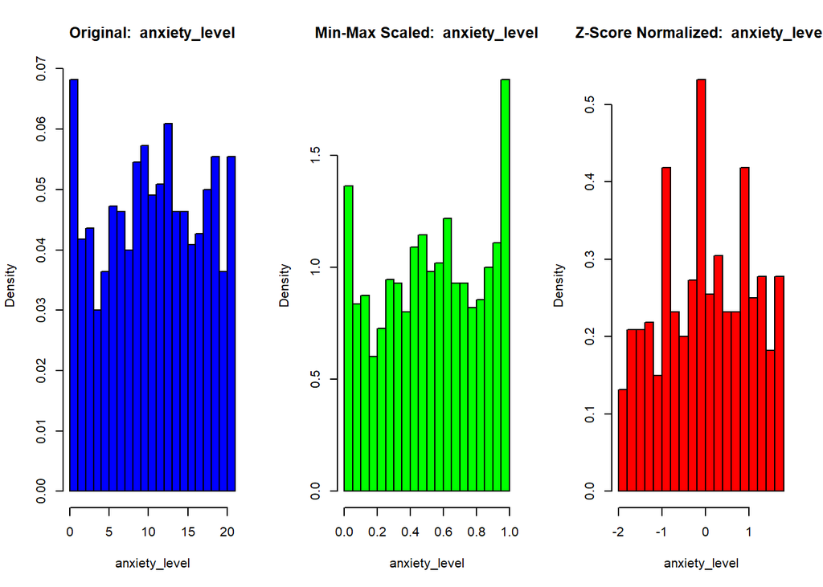

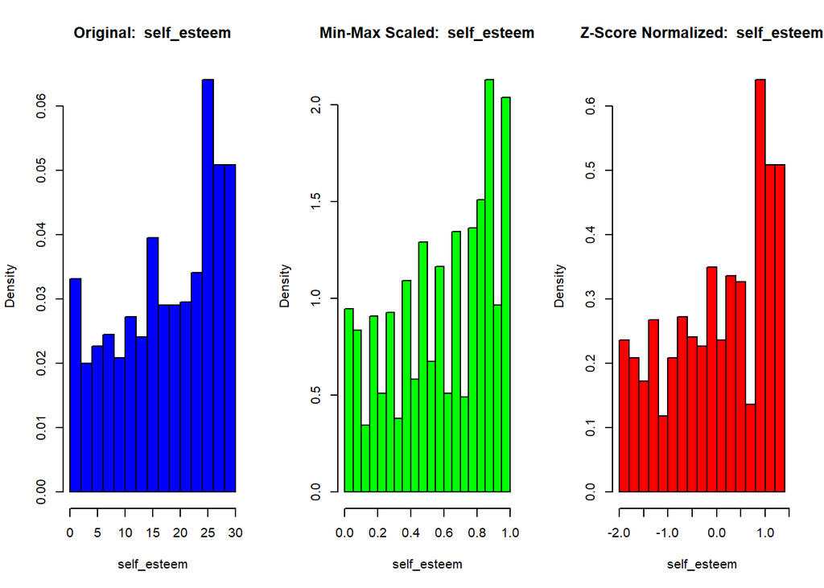

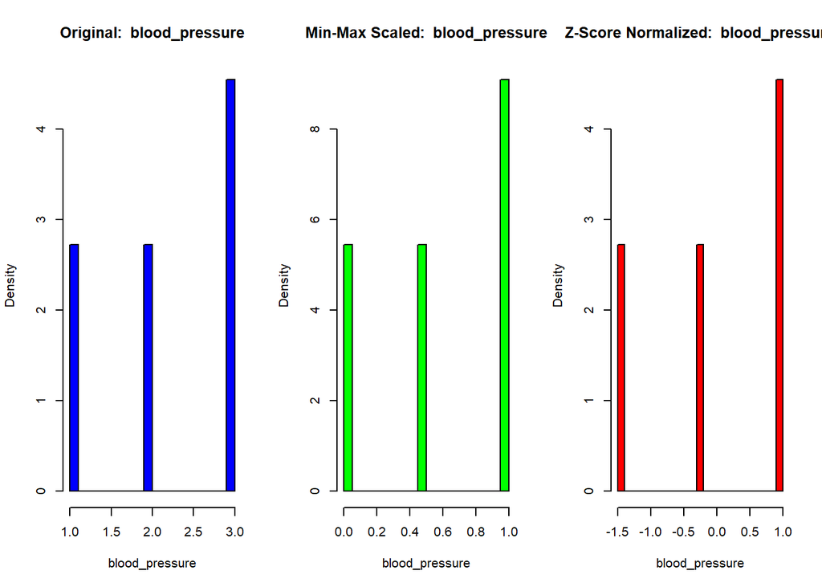

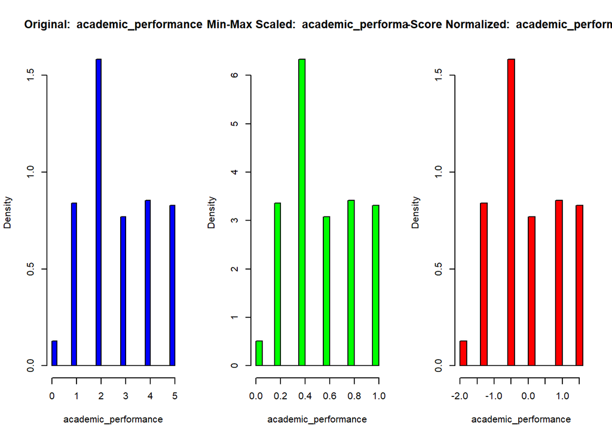

```r
# Función para trazar análisis univariante para una columna dada
plot_univariate_analysis <- function(column, data, scaled_data1, scaled_data2) {

  # Crear una ventana gráfica con 3 paneles
  par(mfrow=c(1, 3))

  # Histograma para datos originales
  hist(data[[column]], main=paste("Original: ", column), xlab=column, col="blue", breaks=20, freq=FALSE)

  # Histograma para datos escalados por Min-Max
  hist(scaled_data1[[column]], main=paste("Min-Max Scaled: ", column), xlab=column, col="green", breaks=20, freq=FALSE)

  # Histograma para datos normalizados por Z-score
  hist(scaled_data2[[column]], main=paste("Z-Score Normalized: ", column), xlab=column, col="red", breaks=20, freq=FALSE)
}

# Características seleccionadas para demostrar el enfoque
selected_features <- c('anxiety_level', 'self_esteem', 'blood_pressure', 'academic_performance')

# Generar gráficos para las características seleccionadas
for (feature in selected_features) {
  plot_univariate_analysis(feature, df, df_minmax, df_zscore)
}
```

#### Academic Performance:

These visualizations give us valuable insights into each feature’s distribution, which can be useful for feature selection and model building later on. It also helps in understanding how scaling methods affect the distribution.

### Bivariate and Multivariate Analysis

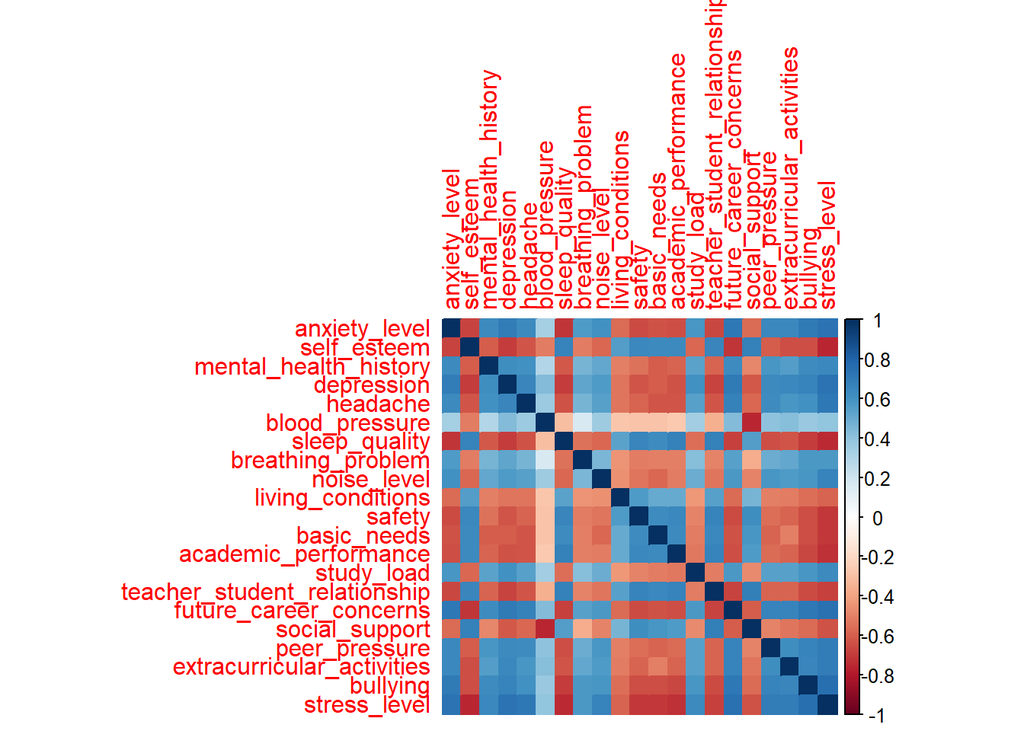

```r
# Cargar la biblioteca para gráficos de correlación
library(corrplot)
# Calcular la matriz de correlación
cor_matrix <- cor(df, use = "complete.obs")

# Dibujar la matriz de correlación
corrplot(cor_matrix, method = "color")
```

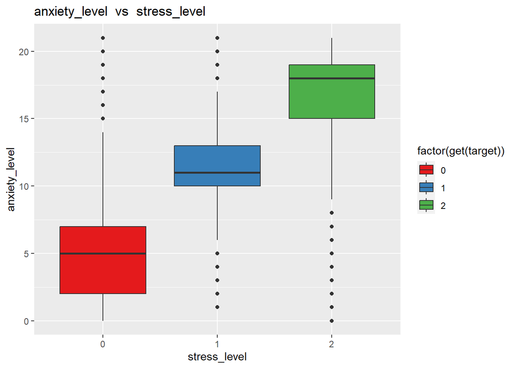

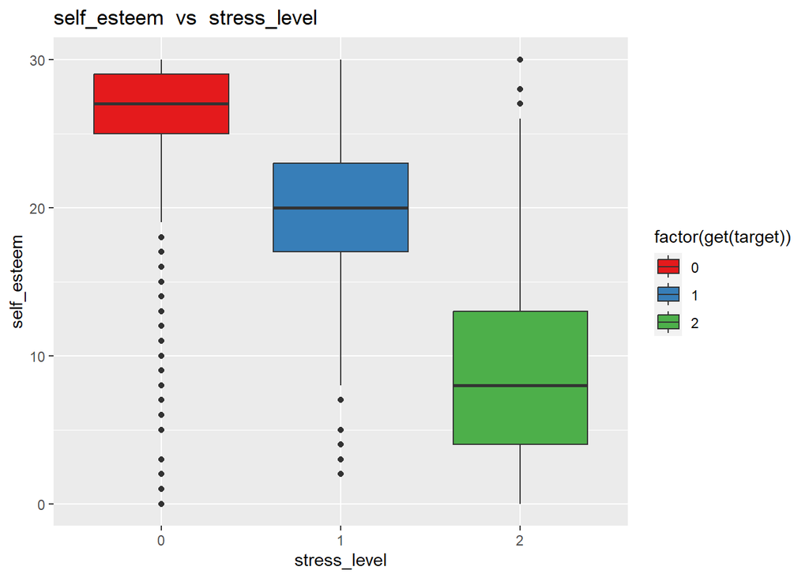

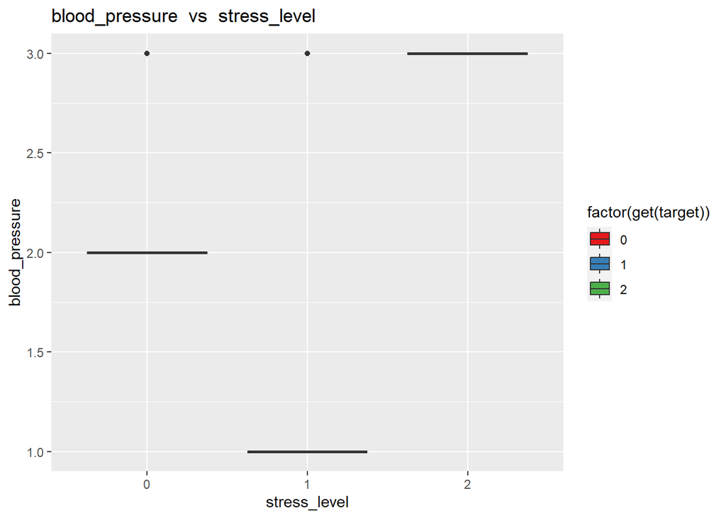

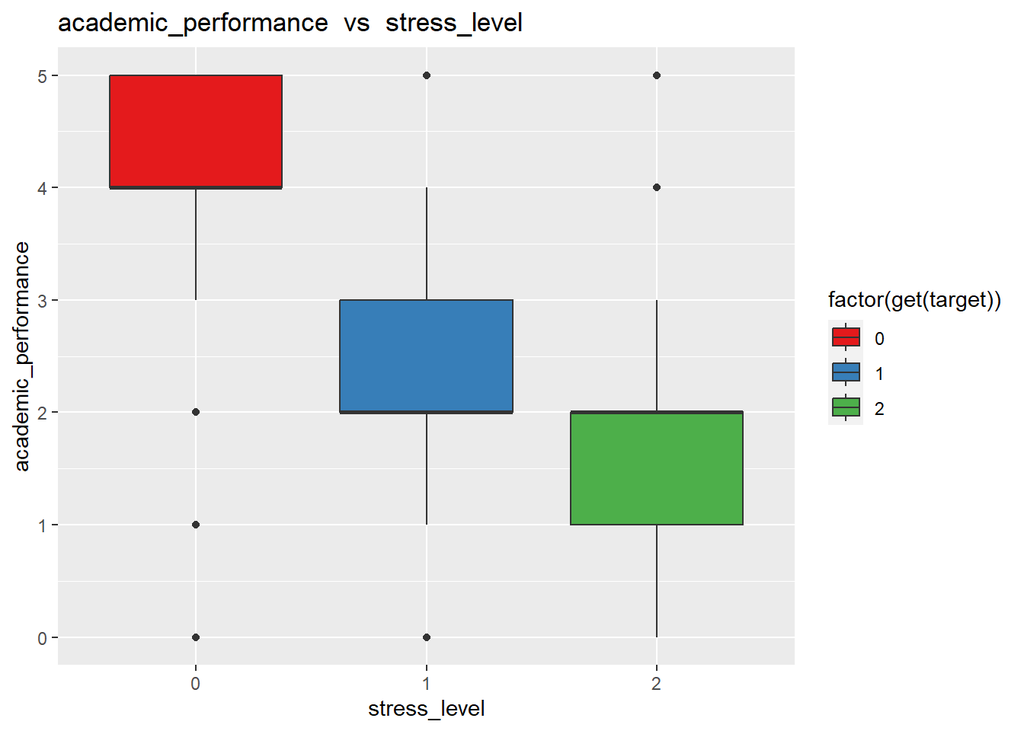

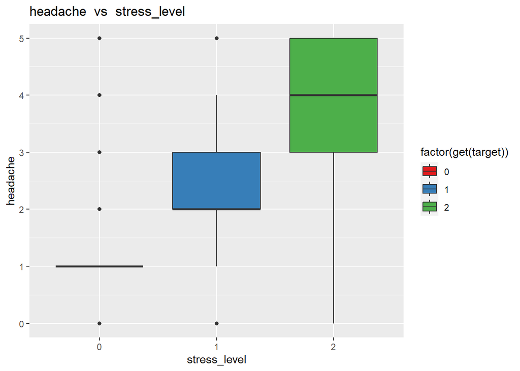

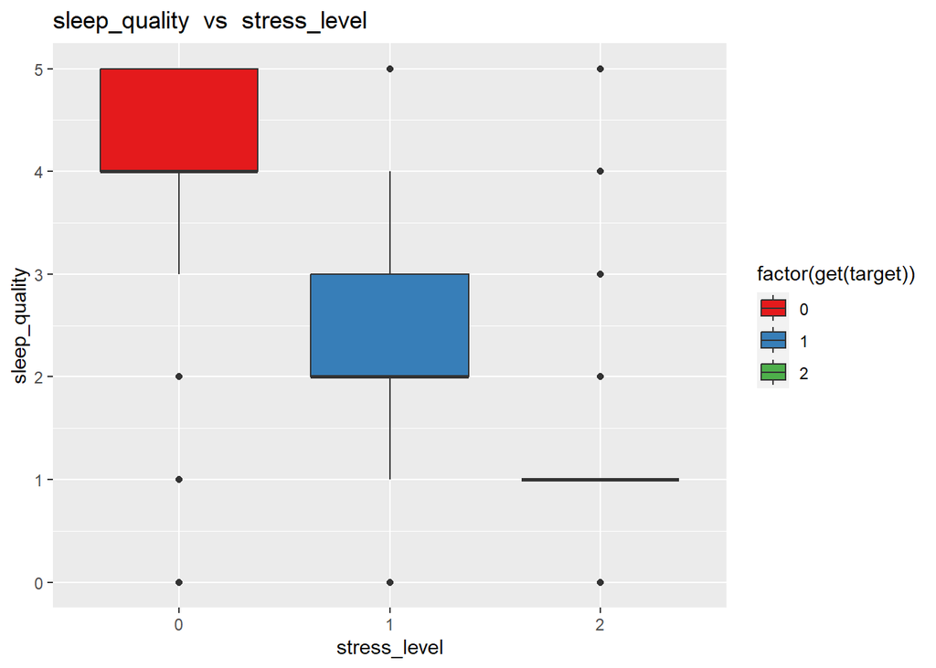

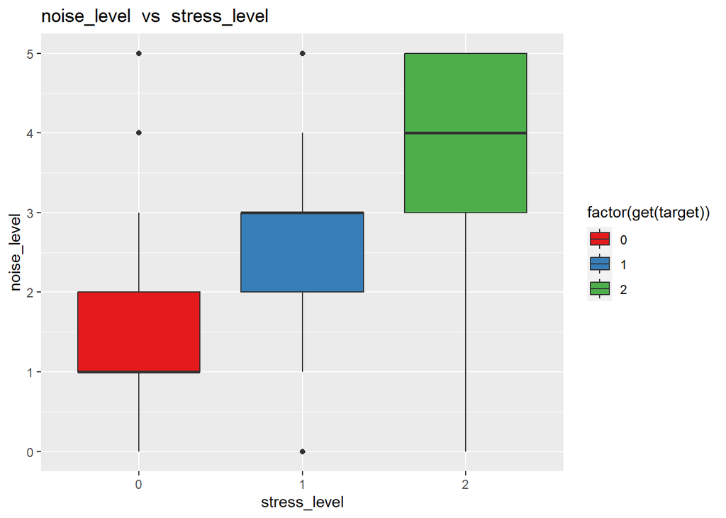

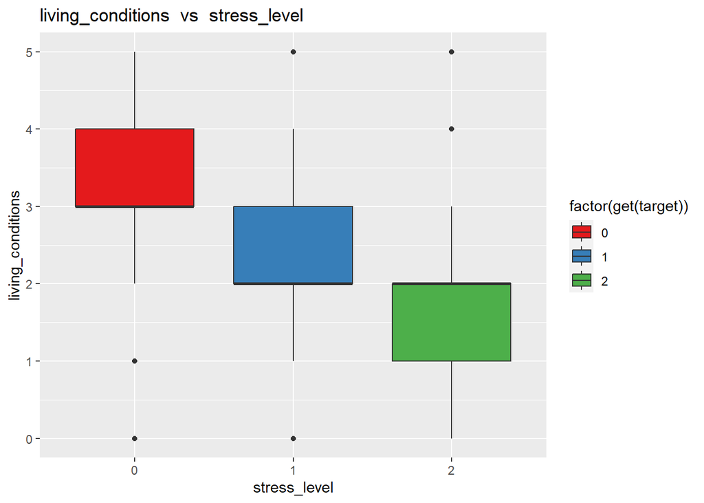

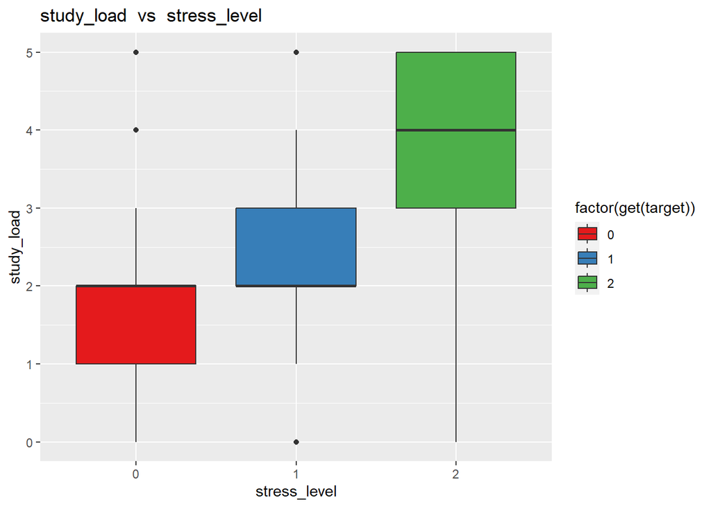

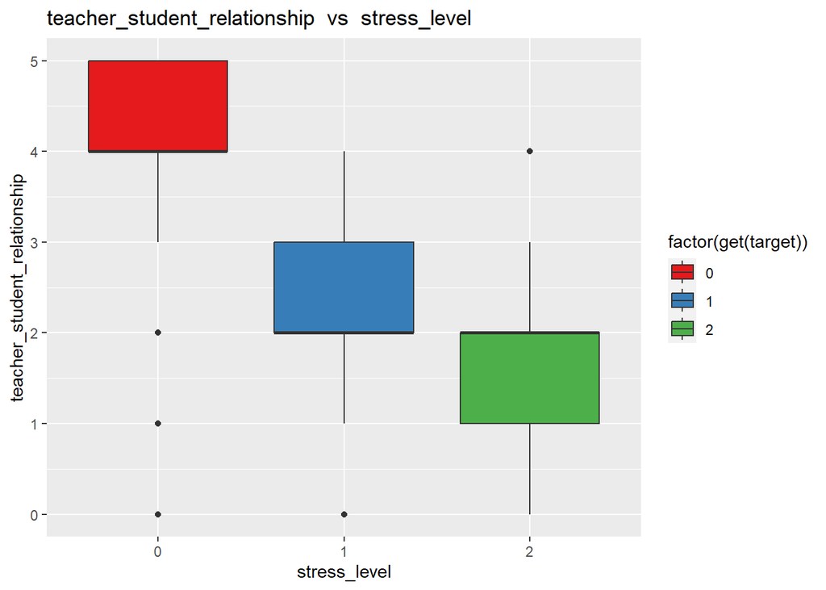

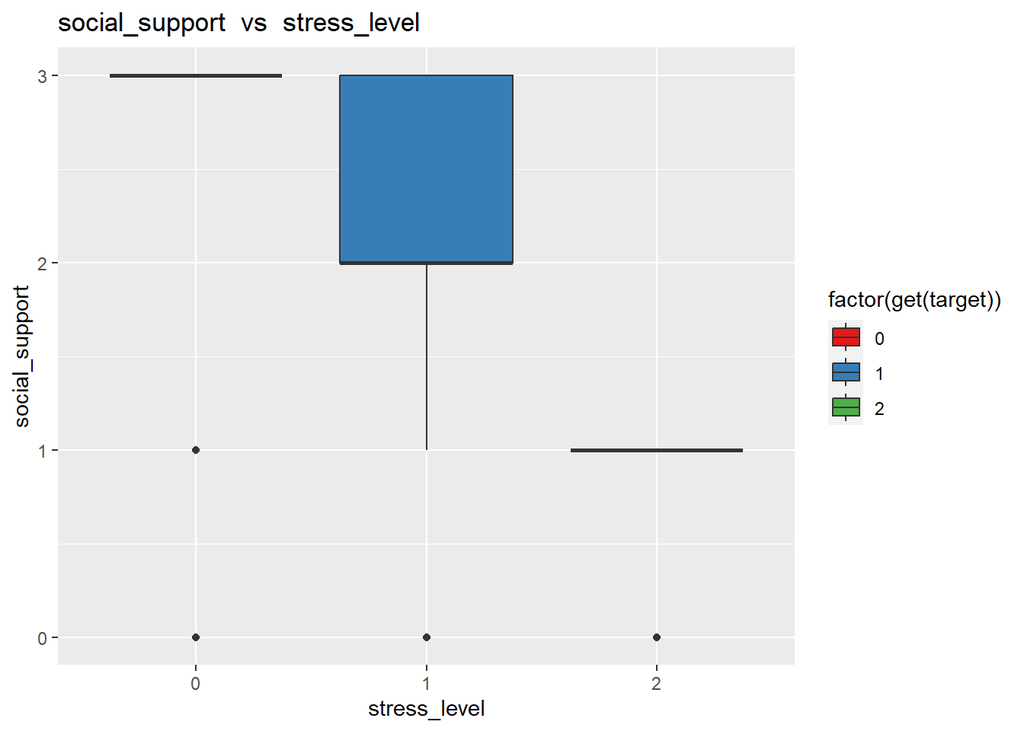

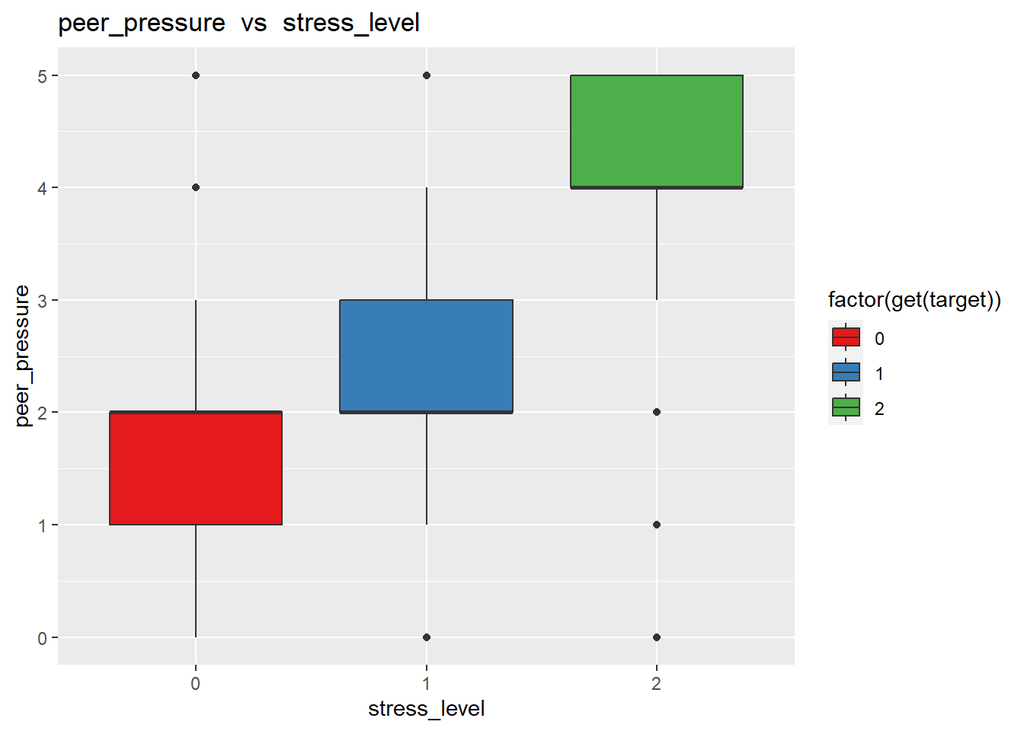

[2 more figures not shown]

```r
# Función corregida para trazar gráficos de caja con colores
plot_bivariate_analysis <- function(target, features, data) {
  for (feature in features) {
    p <- ggplot(data, aes(x=factor(get(target)), y=get(feature), fill=factor(get(target)))) +
      geom_boxplot() +
      scale_fill_brewer(palette="Set1") +
      ggtitle(paste(feature, " vs ", target)) +
      xlab(target) +
      ylab(feature)
    print(p)
  }
}

# Características seleccionadas
selected_features <- c('anxiety_level', 'self_esteem', 'blood_pressure', 'academic_performance',
                       'headache', 'sleep_quality', 'noise_level', 'living_conditions',
                       'study_load', 'teacher_student_relationship',
                       'social_support', 'peer_pressure', 'extracurricular_activities', 'bullying')

# Generar gráficos de caja con colores
plot_bivariate_analysis('stress_level', selected_features, df)
```

```r
# Función para realizar pruebas ANOVA
perform_anova_tests <- function(target, features, data) {
  results <- data.frame(Feature=character(), P_value=numeric())
  for (feature in features) {
    anova_result <- aov(as.formula(paste(target, "~", feature)), data=data)
    p_value <- summary(anova_result)[[1]][["Pr(>F)"]][1]
    results <- rbind(results, data.frame(Feature=feature, P_value=p_value))
  }
  return(results)
}

# Realizar pruebas ANOVA
anova_results <- perform_anova_tests('stress_level', selected_features, df)

# Imprimir los resultados
print(anova_results)
```

```
##                         Feature       P_value
## 1                 anxiety_level 7.533141e-189
## 2                   self_esteem 1.817030e-204
## 3                blood_pressure  3.288295e-42
## 4          academic_performance 4.563269e-177
## 5                      headache 7.991572e-172
## 6                 sleep_quality 1.458711e-198
## 7                   noise_level 1.942314e-140
## 8             living_conditions 1.325429e-100
## 9                    study_load 8.445394e-125
## 10 teacher_student_relationship 2.967654e-150
## 11               social_support 5.808808e-124
## 12                peer_pressure 9.528976e-157
## 13   extracurricular_activities 3.363111e-158
## 14                     bullying 2.816545e-200
```

#### Bivariate and Multivariate Analysis

##### Correlation Matrix:

The heatmap shows the correlation between all the features and the target variable (stress_level). A higher absolute value indicates a stronger relationship.

Features like anxiety_level, depression, and mental_health_history seem to have a relatively higher correlation with stress_level.

##### Bivariate Analysis:

Box plots for the target variable (stress_level) against selected features were plotted.

Anxiety Level: Higher levels of stress appear to be associated with higher anxiety levels.

Self Esteem: Lower stress levels seem to correspond with higher self-esteem.

These analyses can guide feature selection and help in understanding how different features interact with the target variable.

### Statistical Testing

```r
# Función para realizar pruebas t de Student o ANOVA
perform_stat_tests <- function(target, features, data) {
  results <- data.frame(Feature=character(), P_value=numeric())

  for (feature in features) {
    if (length(unique(data[[target]])) == 2) {
      t_result <- t.test(get(feature) ~ get(target), data=data)
      p_value <- t_result$p.value
    } else {
      anova_result <- aov(as.formula(paste(feature, "~", target)), data=data)
      p_value <- summary(anova_result)[[1]][["Pr(>F)"]][1]
    }

    results <- rbind(results, data.frame(Feature=feature, P_value=p_value))
  }

  return(results)
}

# Características seleccionadas para pruebas estadísticas
selected_features <- c('anxiety_level', 'self_esteem', 'blood_pressure', 'academic_performance',
                       'headache', 'sleep_quality', 'noise_level', 'living_conditions',
                       'study_load', 'teacher_student_relationship',
                       'social_support', 'peer_pressure', 'extracurricular_activities', 'bullying')

# Realizar pruebas t de Student o ANOVA
stat_results <- perform_stat_tests('stress_level', selected_features, df)

# Imprimir los resultados
print("Resultados de las pruebas estadísticas:")
```

```
## [1] "Resultados de las pruebas estadísticas:"
```

```r
print(stat_results)
```

```
##                         Feature       P_value
## 1                 anxiety_level 7.533141e-189
## 2                   self_esteem 1.817030e-204
## 3                blood_pressure  3.288295e-42
## 4          academic_performance 4.563269e-177
## 5                      headache 7.991572e-172
## 6                 sleep_quality 1.458711e-198
## 7                   noise_level 1.942314e-140
## 8             living_conditions 1.325429e-100
## 9                    study_load 8.445394e-125
## 10 teacher_student_relationship 2.967654e-150
## 11               social_support 5.808808e-124
## 12                peer_pressure 9.528976e-157
## 13   extracurricular_activities 3.363111e-158
## 14                     bullying 2.816545e-200
```

#### Observations:

All p-values are very close to zero, which suggests that there is a statistically significant difference in these features across different levels of stress.

This confirms the observations made during the bivariate analysis and adds statistical evidence to the relationships.

### Data Visualization - Summary Plots

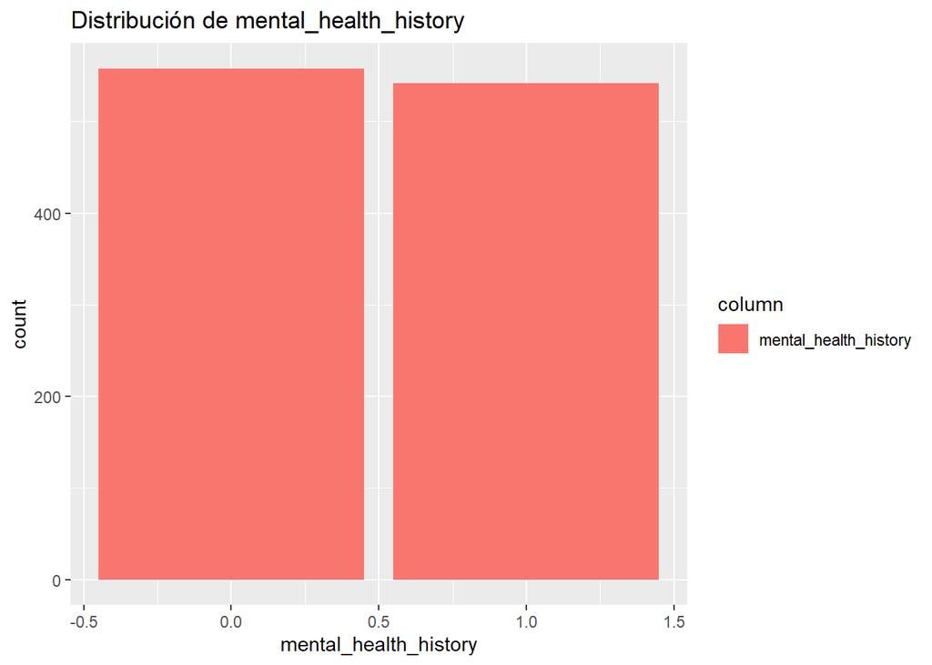

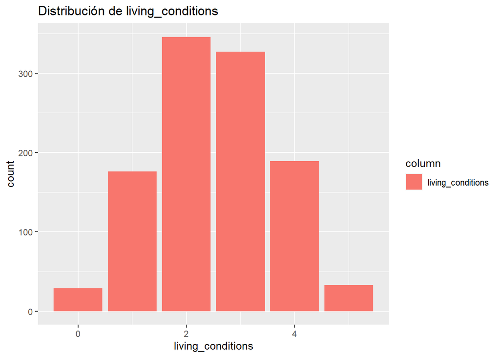

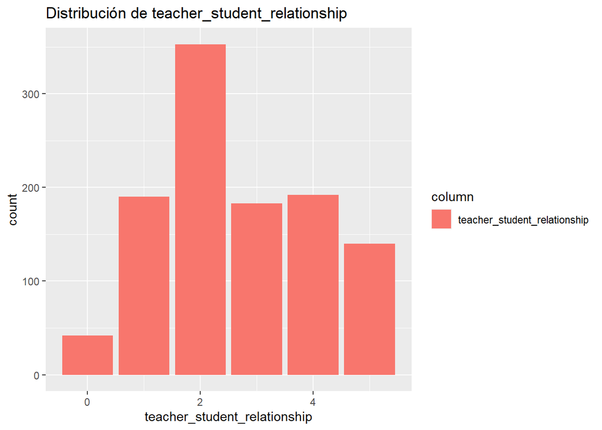

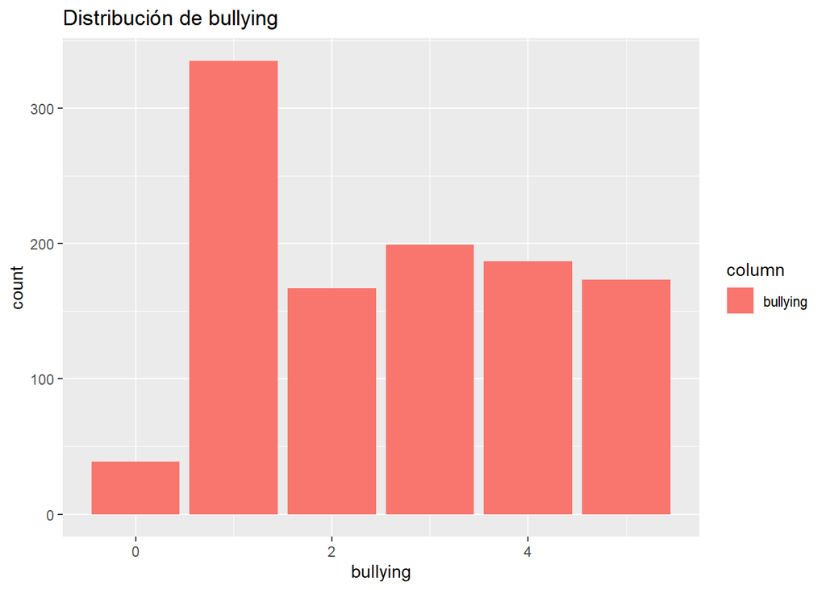

```r
# Función para hacer gráficos de barras para variables categóricas
plot_categorical <- function(column, data) {
  p <- ggplot(data, aes_string(x=column)) +
    geom_bar(aes(fill=column), position="dodge") +
    ggtitle(paste("Distribución de", column))
  print(p)
}

# Características categóricas seleccionadas para visualización
categorical_features <- c('mental_health_history', 'living_conditions', 'teacher_student_relationship', 'bullying')

# Dibujar gráficos de barras
for (feature in categorical_features) {
  plot_categorical(feature, df)
}
```

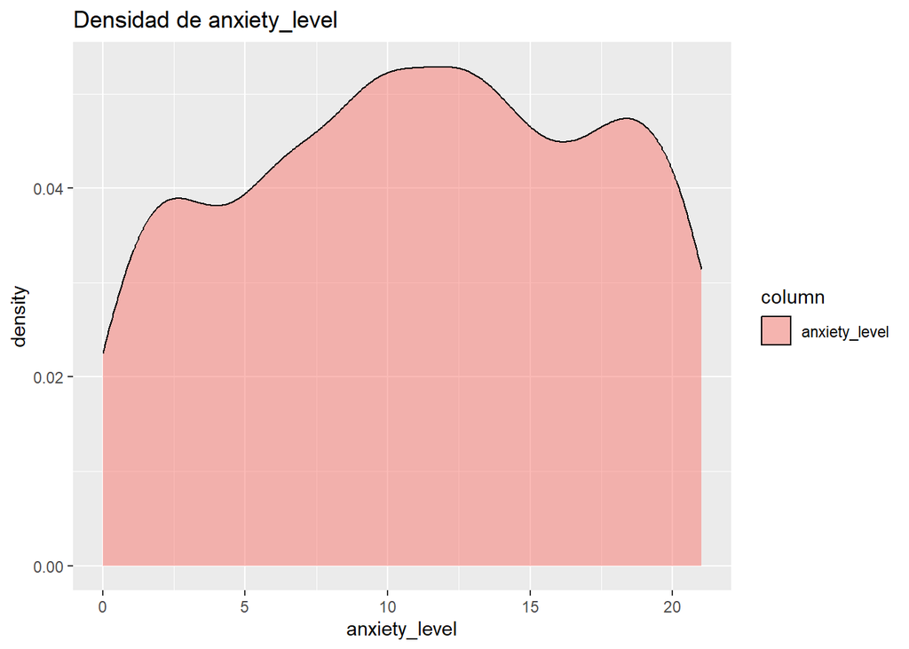

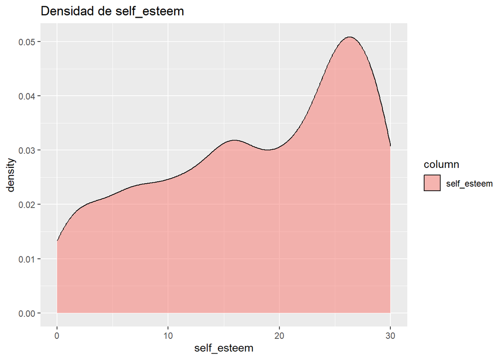

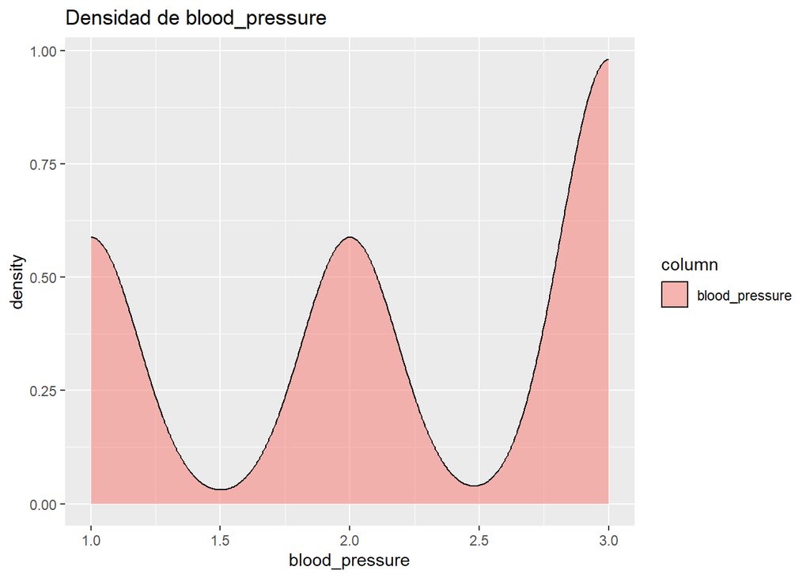

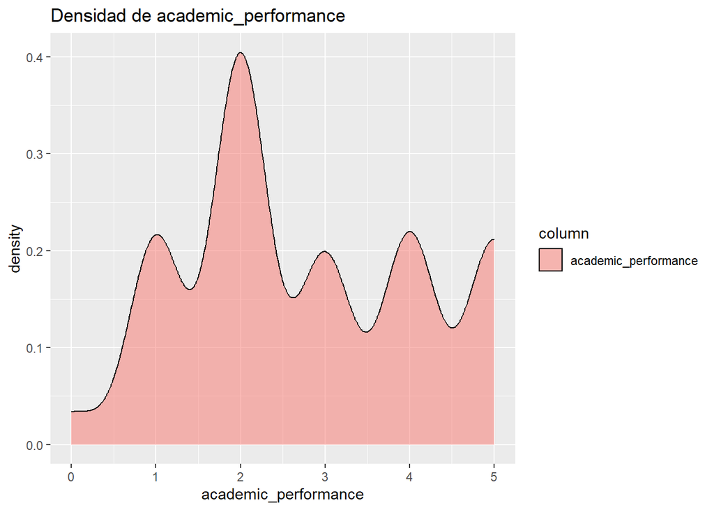

```r
# Función para hacer gráficos de densidad para variables numéricas
plot_density <- function(column, data) {
  p <- ggplot(data, aes_string(x=column)) +
    geom_density(aes(fill=column), alpha=0.5) +
    ggtitle(paste("Densidad de", column))
  print(p)
}

# Características numéricas seleccionadas para visualización
numeric_features <- c('anxiety_level', 'self_esteem', 'blood_pressure', 'academic_performance')

# Dibujar gráficos de densidad
for (feature in numeric_features) {
  plot_density(feature, df)
}
```